# Introduction to Linguistic Theories

#### Quartz Colvin (they/them)

#### Ling 201, Section 2 (Spring 2026)

##### Linguistics Department, Rutgers University

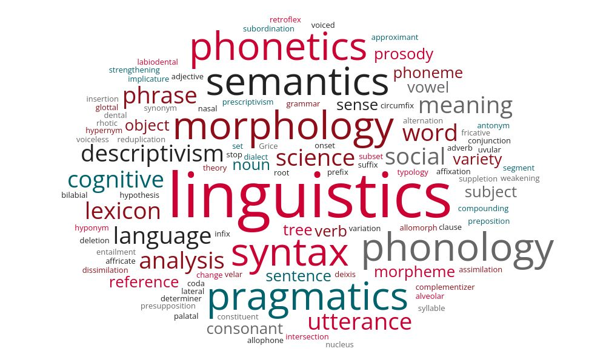

This is an R Markdown document serving as the directory for links to the slides for the course *Introduction to Linguistic Theories* (Spring 2026).

# Schedule

#### **Week 01**: Introduction (Jan 20, 23)

- **Tuesday:** [slides](https://quartz-colvin.github.io/Ling201_Spring2026/intro1)
- **Friday:** [slides](https://quartz-colvin.github.io/Ling201_Spring2026/intro2)

#### **Week 02**: Morphology I (Jan 27, 30)

- **Tuesday:** [slides](https://quartz-colvin.github.io/Ling201_Spring2026/morphology1meet1)
- **Friday:** [slides](https://quartz-colvin.github.io/Ling201_Spring2026/morphology1meet2)

#### **Week 03**: Morphology II (Feb 3, 6)

- **Tuesday:** [slides](https://quartz-colvin.github.io/Ling201_Spring2026/morphology2meet1)
- **Friday:** [slides](https://quartz-colvin.github.io/Ling201_Spring2026/morphology2meet2)
  - **Due Sunday (Feb 8):** HW1

#### **Week 04**: Syntax I (Feb 10, 13)

- **Tuesday:** [slides](https://quartz-colvin.github.io/Ling201_Spring2026/syntax1meet1)
- **Friday:** [slides](https://quartz-colvin.github.io/Ling201_Spring2026/syntax1meet2)
  - **Due Sunday (Feb 15):** HW2

#### **Week 05**: Syntax II (17, 20)

- **Tuesday:** [slides](https://quartz-colvin.github.io/Ling201_Spring2026/syntax2meet1)
- **Friday:** [slides](https://quartz-colvin.github.io/Ling201_Spring2026/syntax2meet2)
  - **Due Sunday (Feb 22):** HW3

#### **Week 06**: Review, Midterm Exam (Feb 24, 27)

- **Tuesday (Review):** [slides](https://quartz-colvin.github.io/Ling201_Spring2026/midterm_review)
- **Friday (Midterm):**
  - **Date**: February 27, 2026
  - **Time**: 12:10 PM - 1:30 PM
  - **Venue**: Scott Hall, Room 116

#### **Week 07**: Semantics I (March 3, 6)

- **Tuesday:** [slides](https://quartz-colvin.github.io/Ling201_Spring2026/semantics1meet1)
- **Friday:** [slides](https://quartz-colvin.github.io/Ling201_Spring2026/semantics1meet2)

#### **Week 08**: Semantics II (March 10, 13)

- **Tuesday:** [slides](https://quartz-colvin.github.io/Ling201_Spring2026/semantics2meet1)
- **Friday:** [slides](https://quartz-colvin.github.io/Ling201_Spring2026/semantics2meet2)
  - **Due Sunday (March 15):** HW4

#### *❀ Spring Break! ❀* *(March 14-22)*

#### **Week 09**: Pragmatics (March 24, 27)

- **Tuesday:** [slides](https://quartz-colvin.github.io/Ling201_Spring2026/pragmatics1meet1)
- **Friday:** [slides](https://quartz-colvin.github.io/Ling201_Spring2026/pragmatics1meet2)
  - **Due Sunday (March 29):** HW5

#### **Week 10**: Phonetics I (March 31, April 3)

- **Tuesday:** [slides](https://quartz-colvin.github.io/Ling201_Spring2026/phonetics1meet1)
- **Friday:** [slides](https://quartz-colvin.github.io/Ling201_Spring2026/phonetics1meet2)
  - **IPA Chart:** PDF
  - **Interactive IPA Chart:** [link](https://www.ipachart.com/)

#### **Week 11**: Phonetics II (April 7, 10)

- **Tuesday:** [slides](https://quartz-colvin.github.io/Ling201_Spring2026/phonetics2meet1)
- **Friday:** [slides](https://quartz-colvin.github.io/Ling201_Spring2026/phonetics2meet2)
  - **Due Sunday (April 12):** HW6

#### **Week 12**: Phonology I (April 14, 17)

- **Tuesday:** [slides](https://quartz-colvin.github.io/Ling201_Spring2026/phonology1meet1)
- **Friday:** [slides](https://quartz-colvin.github.io/Ling201_Spring2026/phonology1meet2)
  - **Due Sunday (April 19):** HW7

#### **Week 13**: Phonology II (April 21, 24)

- **Tuesday:** [slides](https://quartz-colvin.github.io/Ling201_Spring2026/phonology2meet1)
- **Friday:** [slides](https://quartz-colvin.github.io/Ling201_Spring2026/phonology2meet2)

#### **Week 14**: Review (April 28, May 1)

- **Tuesday:** [slides](https://quartz-colvin.github.io/Ling201_Spring2026/final_review)
- **Friday:** [slides](https://quartz-colvin.github.io/Ling201_Spring2026/final_review)
  - **Due Sunday (May 3):** HW8

#### **Week 15**: Final Exam (May 8)

- **Date**: May 8, 2026
- **Time**: 8:00 AM - 11:00 AM
- **Venue**: Scott Hall, Room 116